# Ridge Model

### Load dataset

For this model, we will use the following training and testing datasets:

- `prediction_dataset.csv`: For prediction purposes
- `regression_dataset.csv`: For training and regression purposes
- `vnm_.csv`: For constraints purposes

All data sets have been cleaned and contain no missing values.

```r
# Regression Dataset
regression_data <- read.csv(file.path(data_dir, "training_data/regression_dataset.csv"))

# Prediction Dataset
prediction_data <- read.csv(file.path(data_dir, "training_data/prediction_dataset.csv"))

# National GDP totals used to constrain the regression fit
constrained_data <- read.csv(file.path(data_dir, "_vnm_indicators/vnm_level0_gdp.csv"))

# Provincial GRDP per-capita targets used to calibrate 2025 level-2 predictions
provincial_grdp_data <- read.csv(file.path(data_dir,
  "_vnm_indicators/vnm_GRDPpc.csv"),
  check.names = FALSE
)

# Provincial population totals (thousands) used as the aggregation constraint
provincial_population_data <- read.csv(file.path(data_dir,
  "_vnm_indicators/vnm_population.csv"),
  check.names = FALSE
)

# Provincial population data are in thousands; convert to persons.
regression_data$population <- regression_data$population * 1000
provincial_population_data[, as.character(2020:2025)] <-
  provincial_population_data[, as.character(2020:2025)] * 1000
```

### Splitting the Training and Testing Sets

This setup performs the following tasks:

- Splits the data into a training set (2020–2024) and a holdout test set (2025).
- Selects `mean_radiance`, `population`, and `pixel_count` as the predictor variables.
- Standardizes the features in both the training and testing sets using the means and standard deviations calculated from the training data.
- Calculates the temporal extrapolation weights based on the training years

The temporal extrapolation weights is calculated as
$$w_t = \frac{1}{T}
+ \frac{(2025-\bar{t})(t-\bar{t})}
{\sum_{j=1}^{T}(t_j-\bar{t})^2}.$$

where

- $T = 5$: number of training years
- $t$: individual training years
- $\bar{t}$: mean training years

```r
model_data <- prepare_model_setup(regression_data)

X_train <- model_data$X_train
y_train <- model_data$y_train
X_test  <- model_data$X_test
y_test  <- model_data$y_test
temporal_weights = model_data$temporal_weights
training_data = model_data$training_data
holdout_data = model_data$holdout_data
training_years = model_data$training_years
holdout_year = model_data$holdout_year
y_train_raw = model_data$y_train_raw
y_test_raw = model_data$y_test_raw
feature_columns = model_data$feature_columns
feature_means = model_data$feature_means
feature_sds = model_data$feature_sds
response_mean = model_data$response_mean
response_sd = model_data$response_sd
```

### Prepare OLS references

Ordinary Least Squares (OLS) is used as a baseline reference model to evaluate predictions on both the training and holdout sets (2025). It also provides baseline performance metrics, including $R^2$ and RMSE, for comparison with more advanced models.

```r
ols_comparison <- fit_ols_comparison(model_data)

ols_coefficients <- ols_comparison$coefficients
ols_training_predictions <- ols_comparison$training
ols_holdout_predictions <- ols_comparison$holdout
ols_metrics <- ols_comparison$metrics
ols_training_predictions <- ols_comparison$training$predicted
ols_holdout_predictions <- ols_comparison$holdout$predicted
```

### Preliminaries

Supposed:

- $y \in \mathbb{R}^n$: observed outcome vector. That is, `grdp_per_capita`.
- $x_i \in \mathbb{R}^3$: standardized explanatory variables for observation $i$: `mean_radiance`, `population`, and `pixel_count`.
- $\alpha_t \in \mathbb{R}$: year-specific intercept for year $t$.
- $P_i \in \mathbb{R}$: `population` for observation $i$
- $\beta \in \mathbb{R}^3$: shared coefficients for the explanatory variables.
- $a_t \in \mathbb{R}$: specified national GDP total for year $t$.
- $\lambda$: ridge penalty.

#### Lambda: Ridge penalty

For the choice of lambda, we search evaluates 97 logarithmically spaced penalties from $10^{-3}$ through $10^3$.

```r
# lambda_grid: logarithmically spaced ridge penalty grid from 10^-3 to 10^3.
lambda_grid <- 10^seq(-3, 3, length.out = 97)
```

### Optimization problem

We define the ridge model optimization problem
$$\boxed{
\begin{aligned}
\min_{\alpha,\beta}\quad &
\|y-\hat y\|_2^2+\lambda\|\beta\|_2^2\\
\text{s.t.}\quad
&\sum_{i:\,\mathrm{year}_i=t} P_i\hat y_i=a_t,
\quad t\in\{2020,\ldots,2024\},\\
&\hat y_{it}=\alpha_t+x_i^\top\beta,
\quad t\in\{2020,\ldots,2024\},\\
\quad \lambda\ge 0.
\end{aligned}
}$$
The model is fitted using the 2020–2024 training data with the shared standardized response and design matrix. Note that equality constraints convert standardized predictions back to original units before applying population weights. Only the standardized feature slopes $\beta$ are penalized. The yearly intercepts remain unpenalized.

```r
# Initialize storage for model results.

# T: number of training years
T <- length(training_years)

# p: number of feature columns
p <- ncol(X_train) - T

# solver_status: solver status on each lambda
solver_status <- rep(NA_character_, length(lambda_grid))

# alpha_hat: estimated year effect coefficients
alpha_hat <- matrix(
  NA_real_,
  nrow = T,
  ncol = length(lambda_grid)
)

# beta_hat: estimated coefficients
beta_hat <- matrix(
  NA_real_,
  nrow = p,
  ncol = length(lambda_grid)
)

# training_predictions: predictions on training data
training_predictions <- matrix(
  NA_real_,
  nrow = nrow(training_data),
  ncol = length(lambda_grid)
)

# holdout_predictions: predictions on testing data
holdout_predictions <- matrix(
  NA_real_,
  nrow = nrow(holdout_data),
  ncol = length(lambda_grid)
)
```

The following code chunk fits the model using each candidate lambda and generates predictions for both the training and holdout datasets.

```r
# target_gdp: level 0 gdp, a_t
target_gdp <- constrained_data$gdp[
  match(training_years, constrained_data$year)
]

# Evaluate each candidate lambda using constrained ridge regression.
for (lambda_index in seq_along(lambda_grid)) {

  # alpha: year effect variables
  alpha <- Variable(T)

  # beta: optimization variables
  beta <- Variable(p)

  # theta: stack alpha and beta together
  theta <- vstack(alpha, beta)

  # y_hat_scaled: predicted y using scaled X
  y_hat_scaled <- X_train %*% theta

  # y_hat: predicted y scaled back to original unite
  y_hat <- response_mean +
    response_sd * y_hat_scaled

  # Define the annual GDP constraints for training years only.
  constraints <- lapply(seq_along(training_years), function(i) {
    idx <- which(training_data$year == training_years[i])
    sum_entries(training_data$population[idx] * y_hat[idx]) / target_gdp[i] == 1
  })

  # Define the constrained ridge regression optimization problem.
  problem <- Problem(
    Minimize(
      sum_squares(y_train - y_hat_scaled) +
        lambda_grid[lambda_index] *
        sum_squares(beta)
    ),
    constraints
  )

  # Solve the optimization problem
  suppressMessages({
  result <- solve(problem, solver = "CLARABEL")
  })

  # Record the solver status for the current lambda.
  solver_status[lambda_index] <- result$status

  if (result$status %in% c("optimal", "optimal_inaccurate")) {

    # alpha_hat: estimated year effect coefficients
    alpha_hat[, lambda_index] <- value(alpha)

    # beta_hat: estimated coefficients
    beta_hat[, lambda_index] <- value(beta)

    # theta_hat: stacked alpha_hat and beta_hat
    theta_hat <- c(alpha_hat[, lambda_index], beta_hat[, lambda_index])

    # training_predictions: predictions on training data
    training_predictions[, lambda_index] <-
    as.vector(X_train %*% theta_hat) *
      response_sd + response_mean

    # holdout_predictions: predictions on testing data
    holdout_predictions[, lambda_index] <-
    as.vector(X_test %*% theta_hat) *
      response_sd + response_mean
  }
}
```

### Model Evaluation and Hyperparameter Selection

For each data split, the mean and total sum of squares (SST) are calculated using the observed GRDP-per-capita values within that split. We evaluate model performance using the following metrics.

The coefficient of determination ($R^2$) is calculated for each model as

$$R^2
= 1-\frac{\sum_{i=1}^{n}(y_i-\hat y_i)^2}{\mathrm{SST}},$$

where

$$\bar y = \frac{1}{n}\sum_{i=1}^{n} y_i,
\qquad
\mathrm{SST} = \sum_{i=1}^{n}(y_i-\bar y)^2.$$

We also calculate the root mean squared error (RMSE), expressed in the original GRDP-per-capita units, as

$$\mathrm{RMSE}
=\sqrt{\frac{1}{n}\sum_{i=1}^{n}(y_i-\hat y_i)^2}.$$

```r
# Prepare diagnostics.
training_diagnostics <- lapply(seq_along(lambda_grid), function(lambda_index) {
  prepare_model_diagnostics(
    data = training_data,
    fitted = training_predictions[, lambda_index],
    model_name = "Constrained Ridge Model",
  )
})

holdout_diagnostics <- lapply(seq_along(lambda_grid), function(lambda_index) {
  prepare_model_diagnostics(
    data = holdout_data,
    fitted = holdout_predictions[, lambda_index],
    model_name = "Constrained Ridge Model",
  )
})

lambda_results <- data.frame(
  lambda = lambda_grid,

  # Training diagnostics
  training_RMSE = sapply(training_diagnostics, function(x) {
    x$metrics$RMSE
  }),
  training_R_squared = sapply(training_diagnostics, function(x) {
    x$metrics$R_squared
  }),

  # Holdout diagnostics
  holdout_RMSE = sapply(holdout_diagnostics, function(x) {
    x$metrics$RMSE
  }),
  holdout_R_squared = sapply(holdout_diagnostics, function(x) {
    x$metrics$R_squared
  }),

  # Retain the optimization status for each candidate lambda.
  solver_status = solver_status
)

# Save
write.csv(
  lambda_results,
  file.path(data_output_dir, "ridge_lambda_grid_diagnostic_metrics.csv"),
  row.names = FALSE
)
```

We select the optimal $\lambda$ from the candidate grid based on the holdout performance, aiming to minimize RMSE and maximize $R^2$.

```r
# Select the lambda that minimizes the 2025 holdout RMSE.
selected_index <- which.min(lambda_results$holdout_RMSE)
selected_lambda <- lambda_results$lambda[selected_index]

# Get training and holdout diagnostics of selected lambda.
opt_training_diagnostics <- prepare_model_diagnostics(
  training_data,
  training_predictions[, selected_index],
  ols_training_predictions,
  "Constrained Ridge Model",
  "OLS"
)
opt_holdout_diagnostics <- prepare_model_diagnostics(
  holdout_data,
  holdout_predictions[, selected_index],
  ols_holdout_predictions,
  "Constrained Ridge Model",
  "OLS"
)

# Report the selected lambda and evaluation metrics.
cat("Selected lambda by minimum 2025 holdout RMSE: ")
```

```
## Selected lambda by minimum 2025 holdout RMSE:
```

```r
print(selected_lambda)
```

```
## [1] 13.33521
```

```r
# Save
write.csv(
  opt_training_diagnostics$diagnostics,
  file.path(data_output_dir, "ridge_model_training_diagnostics.csv"),
  row.names = FALSE
)
write.csv(
  opt_holdout_diagnostics$diagnostics,
  file.path(data_output_dir, "ridge_model_holdout_diagnostics.csv"),
  row.names = FALSE
)
model_comparison_metrics <- bind_rows(
  Training = opt_training_diagnostics$metrics,
  Holdout = opt_holdout_diagnostics$metrics,
  .id = "Dataset"
)
write.csv(
  model_comparison_metrics,
  file.path(data_output_dir, "ridge_model_comparison_metrics.csv"),
  row.names = FALSE
)
```

#### Lambda sensitivity analysis

The vertical line and highlighted point mark the selected $\lambda$.

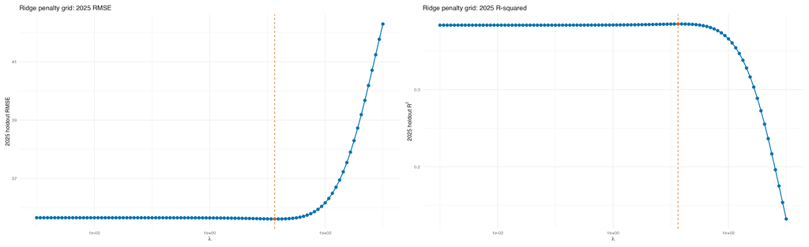

```r
ridge_lambda_metrics_plot <- plot_ridge_lambda_metrics(
  lambda_results,
  selected_lambda
)

# Save and display
ridge_lambda_metrics_path <- file.path(
  figure_output_dir,
  "ridge_lambda_grid_metrics.png"
)
ggsave(
  ridge_lambda_metrics_path,
  ridge_lambda_metrics_plot,
  width = 22.5,
  height = 6.875,
  dpi = 160
)

knitr::include_graphics(ridge_lambda_metrics_path)
```

### Residual Diagnostics

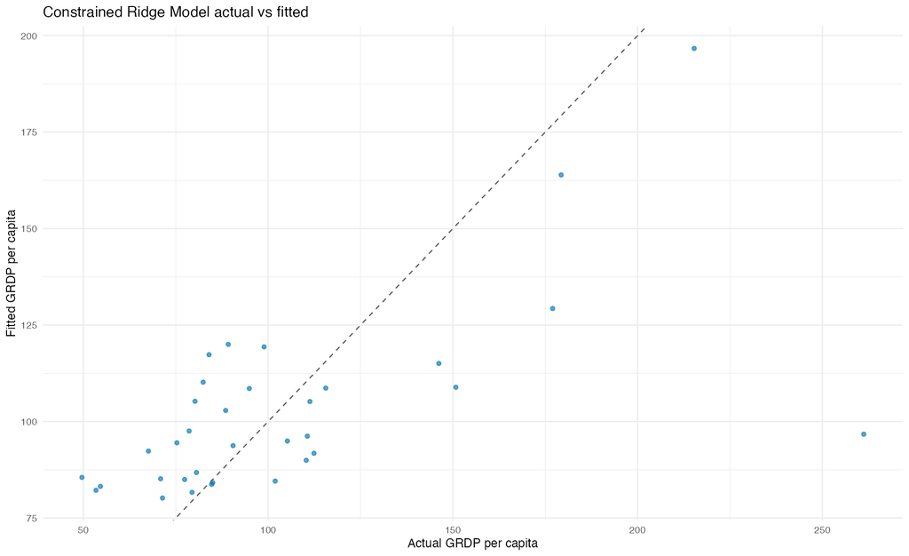

```r
# Plot holdout actual vs fitted.
holdout_actual_fitted_plot <- plot_actual_vs_fitted(
  holdout_data,
  holdout_predictions[, selected_index],
  "Constrained Ridge Model"
)

# Save and display
holdout_actual_fitted_path <- file.path(
  figure_output_dir,
  "ridge_model_holdout_actual_vs_fitted.png"
)
ggsave(
  holdout_actual_fitted_path,
  holdout_actual_fitted_plot,
  width = 11.25,
  height = 6.875,
  dpi = 160
)

knitr::include_graphics(holdout_actual_fitted_path)
```

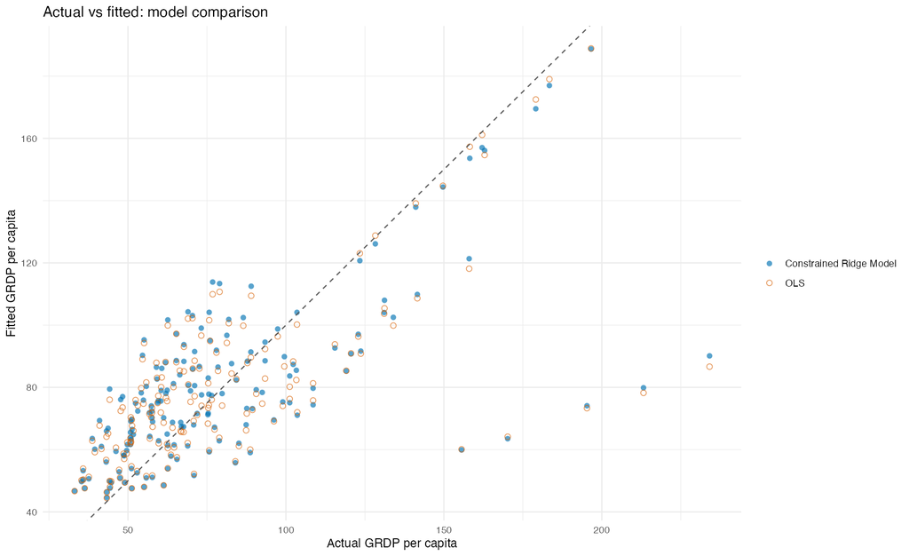

```r
training_model_comparison_plot <- plot_model_comparison(
  training_data,
  training_predictions[, selected_index],
  ols_training_predictions,
  "Constrained Ridge Model",
  "OLS"
)

# Save and display
training_comparison_path <- file.path(
  figure_output_dir,
  "ridge_model_training_actual_vs_fitted_comparison.png"
)
ggsave(
  training_comparison_path,
  training_model_comparison_plot,
  width = 11.25,
  height = 6.875,
  dpi = 160
)

knitr::include_graphics(training_comparison_path)
```

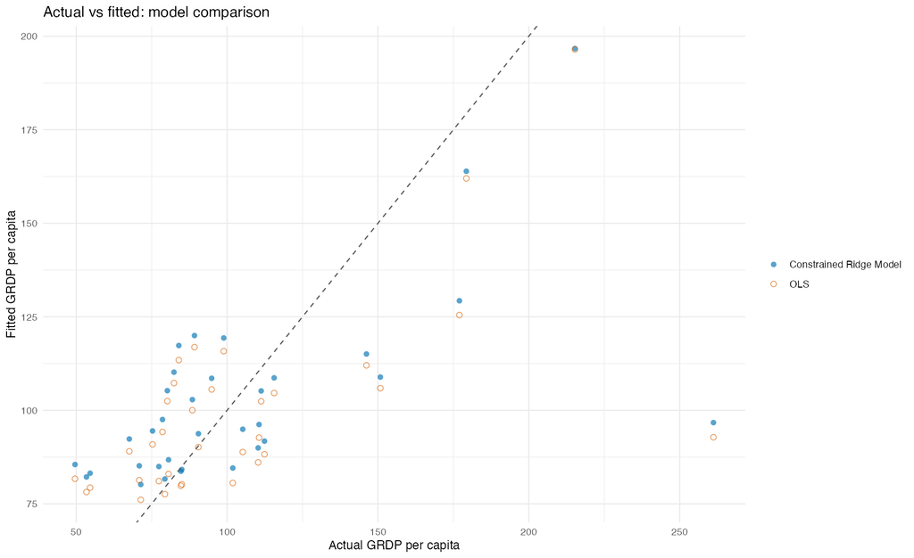

```r
holdout_model_comparison_plot <- plot_model_comparison(
  holdout_data,
  holdout_predictions[, selected_index],
  ols_holdout_predictions,
  "Constrained Ridge Model",
  "OLS"
)

# Save and display
holdout_comparison_path <- file.path(
  figure_output_dir,
  "ridge_model_holdout_actual_vs_fitted_comparison.png"
)
ggsave(
  holdout_comparison_path,
  holdout_model_comparison_plot,
  width = 11.25,
  height = 6.875,
  dpi = 160
)

knitr::include_graphics(holdout_comparison_path)
```

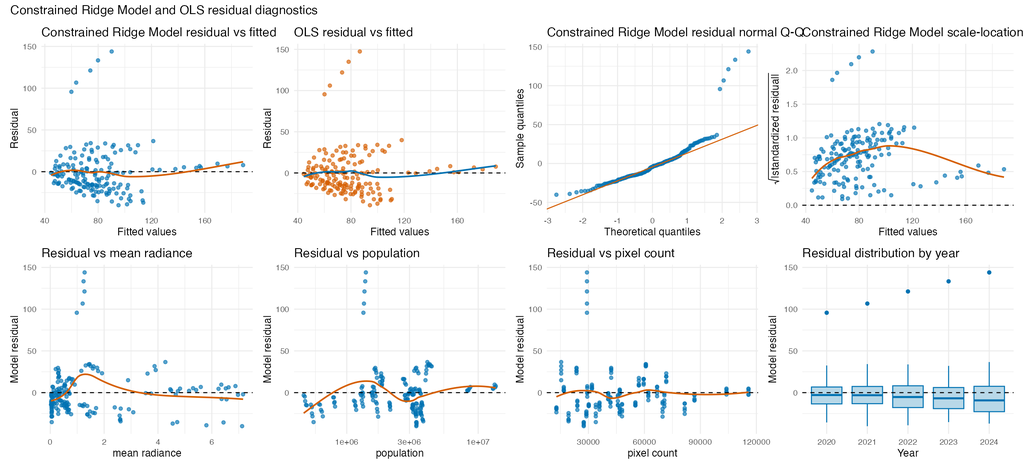

```r
# Plot training diagnostic plots.
training_plots <- plot_residual_diagnostics(
  opt_training_diagnostics$diagnostics,
  "Constrained Ridge Model",
  "OLS"
)

# Save and display
training_diagnostics_path <- file.path(
  figure_output_dir,
  "ridge_model_training_residual_diagnostics.png"
)
ggsave(
  training_diagnostics_path,
  training_plots$combined,
  width = 15,
  height = 6.875,
  dpi = 160
)

knitr::include_graphics(training_diagnostics_path)
```

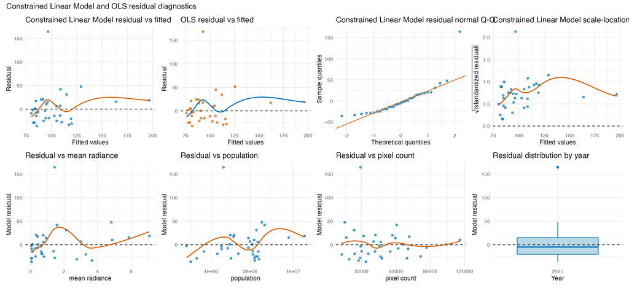

```r
# Plot holdout diagnostic plots.
holdout_plots <- plot_residual_diagnostics(
  opt_holdout_diagnostics$diagnostics,
  "Constrained Linear Model",
  "OLS"
)

# Save and display
holdout_diagnostics_path <- file.path(
  figure_output_dir,
  "linear_model_holdout_residual_diagnostics.png"
)
ggsave(
  holdout_diagnostics_path,
  holdout_plots$combined,
  width = 15,
  height = 6.875,
  dpi = 160
)

knitr::include_graphics(holdout_diagnostics_path)
```

### Training using all data

Prepare the complete dataset for the full optimization model. All observations are used to standardize the predictor variables and response variable.

```r
full_model_data <- prepare_full_model_setup(regression_data)
X <- full_model_data$X
y <- full_model_data$y
years <- full_model_data$years
feature_columns <- full_model_data$feature_columns
feature_means <- full_model_data$feature_means
feature_sds <- full_model_data$feature_sds
response_mean <- full_model_data$response_mean
response_sd <- full_model_data$response_sd
```

Fit the constrained ridge regression model using all available years.

```r
# T: number of training years
T <- length(years)

# p: number of feature columns
p <- ncol(X) - T

# target_gdp: level 0 gdp, a_t
target_gdp <- constrained_data$gdp[
  match(years, constrained_data$year)
]

# alpha: year effect variables
alpha <- Variable(T)

# beta: optimization variables
beta <- Variable(p)

# theta: stack alpha and beta together
theta <- vstack(alpha, beta)

# y_hat_scaled: predicted y using scaled X
y_hat_scaled <- X %*% theta

# y_hat: predicted y scaled back to original unite
y_hat <- response_mean +
  response_sd * y_hat_scaled

# Define the annual GDP constraints for training years only.
constraints <- lapply(seq_along(years), function(i) {
  idx <- which(regression_data$year == years[i])
  sum_entries(regression_data$population[idx] * y_hat[idx]) / target_gdp[i] == 1
})

# Define the constrained ridge regression optimization problem.
problem <- Problem(
  Minimize(
    sum_squares(y - y_hat_scaled) +
      selected_lambda *
      sum_squares(beta)
  ),
  constraints
)

# Solve
suppressMessages({
result <- solve(problem, solver = "CLARABEL")
})

# Print results
cat("\nOptimization Solver Status:\n")
```

```
##
## Optimization Solver Status:
```

```r
print(result$status)
```

```
## [1] "optimal"
```

```r
if (result$status %in% c("optimal", "optimal_inaccurate")) {

  # alpha_hat: estimated year effect coefficients
  alpha_hat<- value(alpha)

  # beta_hat: estimated coefficients
  beta_hat <- value(beta)

  # theta_hat: stacked alpha_hat and beta_hat
  theta_hat <- c(alpha_hat, beta_hat)

  # predictions: predictions on data
  predictions <- as.vector(X %*% theta_hat) *
    response_sd + response_mean

  # Constraints check
  yearly_check <- data.frame(
    year = years,
    predicted_total_grdp = sapply(years, function(t) {
      idx <- which(regression_data$year == t)
      sum(regression_data$population[idx] * predictions[idx])
    }),
    target_total_grdp = target_gdp
  )

  yearly_check$difference <-
    yearly_check$predicted_total_grdp -
    yearly_check$target_total_grdp

  # Output model
  cat("\nEstimated Model Coefficients:\n")
  print(alpha_hat)
  print(beta_hat)

  cat("\nOptimal Objective Function Value:\n")
  print(result$value)

  cat("\nAnnual GDP Constraint Verification:\n")
  print(yearly_check)

  # Save fitted model
  fitted_model <- local({
    coefficients <- theta_hat
    variable_names <- colnames(X)
    training_years <- years

    feature_means <- feature_means
    feature_sds <- feature_sds

    response_mean <- response_mean
    response_sd <- response_sd

    list(
      coefficients = coefficients,
      variable_names = variable_names,
      years = training_years,
      feature_columns = feature_columns,
      feature_means = feature_means,
      feature_sds = feature_sds,
      response_mean = response_mean,
      response_sd = response_sd,
      solver = "CLARABEL",
      solver_status = result$status,
      objective_value = result$value,

      predict = function(newdata) {
        # Calculate temporal extrapolation weights.
        T <- length(training_years)
        time_index <- seq_len(T)
        time_mean <- mean(time_index)

        target_index <- newdata$year - min(training_years) + 1

        temporal_weights <- sapply(target_index, function(t_star) {
          1 / T +
            (t_star - time_mean) *
            (time_index - time_mean) /
            sum((time_index - time_mean)^2)
        })

        # Standardize prediction features.
        scaled_features <- as.matrix(newdata[feature_columns])
        scaled_features <- sweep(
          scaled_features, 2, feature_means[feature_columns], "-"
        )
        scaled_features <- sweep(
          scaled_features, 2, feature_sds[feature_columns], "/"
        )

        # Construct prediction matrix.
        prediction_X <- cbind(
          t(temporal_weights),
          scaled_features
        )

        colnames(prediction_X) <- variable_names

        # Calculate raw predictions.
        as.vector(prediction_X %*% coefficients) *
          response_sd + response_mean
      }
    )
  })

  model_path = file.path(model_output_dir, "constrained_ridge_model.rds")
  saveRDS(fitted_model, model_path)
  print(paste("Model saved to:", model_path))

} else {
  stop(sprintf("Constrained regression failed with solver status: %s", result$status))
}
```

```
##
## Estimated Model Coefficients:
##             [,1]
## [1,] -0.41588742
## [2,] -0.34843761
## [3,] -0.08810416
## [4,]  0.05577303
## [5,]  0.30460062
## [6,]  0.58607439
##            [,1]
## [1,]  0.1722781
## [2,]  0.3957761
## [3,] -0.1824623
##
## Optimal Objective Function Value:
## [1] 110.3936
##
## Annual GDP Constraint Verification:
##   year predicted_total_grdp target_total_grdp    difference
## 1 2020           8044385730        8044385730  5.531311e-05
## 2 2021           8487475600        8487475600  7.820129e-05
## 3 2022           9621371820        9621371820  1.907349e-05
## 4 2023          10319058870       10319058870 -1.716614e-05
## 5 2024          11510328920       11510328920 -1.049042e-04
## 6 2025          12847571220       12847571220 -1.373291e-04
## [1] "Model saved to: /Users/kien0508/Sync/DA 401/SpatialGDP/code/R/model/ridge_model/constrained_ridge_model.rds"
```

### 2025 Level-2 Predictions

```r
# Setting up prediction data
level2_prediction_data <- prepare_prediction_data(
  prediction_data = prediction_data,
  provincial_grdp_data = provincial_grdp_data,
  provincial_population_data = provincial_population_data,
  feature_columns = feature_columns,
  feature_means = feature_means,
  feature_sds = feature_sds
)
```

The raw prediction is
$$\hat{y}_{i,2025}
=
\sum_{t=1}^{T} w_t \alpha_t
+
\sum_{m=1}^{p} \beta_m X_{mi,2025}$$

```r
# Make raw prediction
raw_predictions <- fitted_model$predict(level2_prediction_data)
level2_prediction_data$raw_predictions <- raw_predictions
```

Next, we adjust these predictions so that their population weighted total matches the province’s reported 2025 GRDP per capita multiplied by its total population.

#### Adjustment Solution 1: Additive adjustment

To do this, we add the same adjustment $\delta_j$ to every level-2 prediction within province $j$:

$$\tilde y_{ij} = \hat y_{ij} + \delta_j$$

The adjustment is calculated as:

$$\delta_j = \frac{g_j\sum_{i\in
j}P_{ij}-\sum_{i\in j}P_{ij}\hat y_{ij}} {\sum_{i\in j}P_{ij}}$$

where $g_j$ is the province’s reported GRDP per capita and $P_{ij}$ is the population of level-2 unit $i$.

```r
# Adjustment Solution 1: Additive adjustment
calculate_additive_adjustments <- function(level2_prediction_data) {

  province_groups <- split(
    seq_len(nrow(level2_prediction_data)),
    level2_prediction_data$level_1
  )

  vapply(province_groups, function(idx) {

    population <- level2_prediction_data$population[idx]

    level2_prediction_data$grdp_pc_2025[idx[1]] -
      weighted.mean(
        level2_prediction_data$raw_predictions[idx],
        population
      )

  }, numeric(1))
}

# Apply additive adjustment
additive_adjustments <- calculate_additive_adjustments(
  level2_prediction_data
)

level2_prediction_data$additive_adjustment <-
  unname(additive_adjustments[level2_prediction_data$level_1])

level2_prediction_data$additive_predictions <-
  level2_prediction_data$raw_predictions +
  level2_prediction_data$additive_adjustment
```

#### Adjustment Solution 2: Proportional scaling

Another approach is to adjust the level-2 predictions by multiplying every prediction within province $j$ by a common scaling factor:

$$s_j = \frac{g_j}{\bar{y}_j},$$

where

$$\bar{y}_j = \frac{\sum_{i=1}^{n_j}
P_{ij}\hat{y}_{ij}} {\sum_{i=1}^{n_j} P_{ij}}$$

is the population-weighted average of the raw level-2 predictions in province $j$. The adjusted prediction for each level-2 unit is then:

$$\tilde {y}_{ij}=s_j\hat{y}_{ij}.$$

```r
# Adjustment Solution 2: Proportional scaling
calculate_scaling_adjustments <- function(level2_prediction_data) {
  province_groups <- split(
    seq_len(nrow(level2_prediction_data)),
    level2_prediction_data$level_1
  )

  vapply(province_groups, function(idx) {

    population <- level2_prediction_data$population[idx]

    predicted_mean <- weighted.mean(
      level2_prediction_data$raw_predictions[idx],
      population
    )

    level2_prediction_data$grdp_pc_2025[idx[1]] /
      predicted_mean

  }, numeric(1))
}

# Apply proportional scaling
scaling_adjustments <- calculate_scaling_adjustments(level2_prediction_data)

level2_prediction_data$scaling_adjustments <-
  unname(scaling_adjustments[level2_prediction_data$level_1])

level2_prediction_data$scaled_predictions <-
  level2_prediction_data$raw_predictions *
  level2_prediction_data$scaling_adjustments
```

```r
# Save prediction results
prediction_output <- file.path(
  data_output_dir,
  "ridge_model_level2_predictions.csv"
)

write.csv(
  level2_prediction_data,
  prediction_output,
  row.names = FALSE
)
```